# Finansal Veri Analizi ve Makine Öğrenmesi ile Gelecek Tahmini Bu projede, veri madenciliği derslerinde gördüğüm teorik bilgileri gerçek zamanlı finansal veriler üzerinde uyguladım. Amacım, Python kütüphanelerini kullanarak veriyi işlemek, görselleştirmek ve basit bir regresyon modeliyle gelecek trendlerini analiz etmektir.

```python
# Gerekli kütüphaneleri projeye dahil ediyoruz.
import yfinance as yf  # Canlı borsa verisi çekmek için
import pandas as pd    # Veri manipülasyonu ve tablolar için
import matplotlib.pyplot as plt # Görselleştirme ve grafikler için
from sklearn.linear_model import LinearRegression # Makine öğrenmesi modeli için
import numpy as np     # Matematiksel hesaplamalar için
from datetime import datetime
```

### Veri Çekme ve Ön İşleme Veri kaynağı olarak Yahoo Finance API'sini (yfinance) kullandım. Argela yerli bir teknoloji devleti olduğu için analizimde USD/TRY kurunu baz aldım. Verideki eksik değerleri (NaN) temizleyerek analize hazır hale getirdim.

```python
# USD/TRY verisini 2024 başından günümüze kadar çekiyoruz
symbol = "USDTRY=X"
df = yf.download(symbol, start="2024-01-01", end=datetime.now().strftime('%Y-%m-%d'))

# Sadece kapanış fiyatlarını (Close) baz alıyoruz ve boş verileri siliyoruz
df = df[['Close']].dropna()

# Makine öğrenmesi modelinin anlayabilmesi için günleri indeksliyoruz (0, 1, 2...)
df['Day_Index'] = np.arange(len(df))

# Verinin ilk 5 satırına göz atalım
df.head()
```

```
[*********************100%***********************]  1 of 1 completed
```

| Price Ticker Date | Close USDTRY=X | Day_Index |
| --- | --- | --- |
| 2024-01-01 | 29.018070 | 0 |
| 2024-01-02 | 29.428200 | 1 |
| 2024-01-03 | 29.744860 | 2 |
| 2024-01-04 | 29.779079 | 3 |
| 2024-01-05 | 29.840900 | 4 |

### Teknik Analiz: Hareketli Ortalama (Moving Average) Fiyattaki ani dalgalanmaları (gürültüyü) yumuşatmak ve genel trendi daha iyi gözlemlemek için 20 günlük hareketli ortalamayı hesapladım. Bu, verinin 'momentumunu' anlamamıza yardımcı oluyor.

```python
# 20 günlük hareketli ortalama hesaplama
df['Moving_Average'] = df['Close'].rolling(window=20).mean()

# Sonuçları kontrol edelim
df.tail()
```

| Price Ticker Date | Close USDTRY=X | Day_Index | Moving_Average |
| --- | --- | --- | --- |
| 2025-12-26 | 42.854500 | 515 | 42.627904 |
| 2025-12-29 | 42.904079 | 516 | 42.648853 |
| 2025-12-30 | 42.935699 | 517 | 42.672162 |
| 2025-12-31 | 42.951981 | 518 | 42.698861 |
| 2026-01-01 | 42.941761 | 519 | 42.723335 |

### Makine Öğrenmesi: Lineer Regresyon Modeli Burada scikit-learn kütüphanesini kullanarak bir Lineer Regresyon modeli kurdum. Model, geçmişteki gün indeksleri (X) ile fiyatlar (y) arasındaki ilişkiyi öğreniyor ve bu doğrusal ilişkiyi geleceğe yansıtarak tahmin üretiyor

```python
# Eğitim verilerini hazırlıyoruz
X = df[['Day_Index']].values
y = df['Close'].values

# Modeli oluşturup eğitiyoruz
model = LinearRegression()
model.fit(X, y)

# Gelecek 30 gün için tahmin yapıyoruz
last_day = df['Day_Index'].max()
future_days = np.arange(last_day + 1, last_day + 31).reshape(-1, 1)
future_preds = model.predict(future_days)

print("Model eğitildi ve 30 günlük tahminler başarıyla oluşturuldu.")
```

```
Model eğitildi ve 30 günlük tahminler başarıyla oluşturuldu.
```

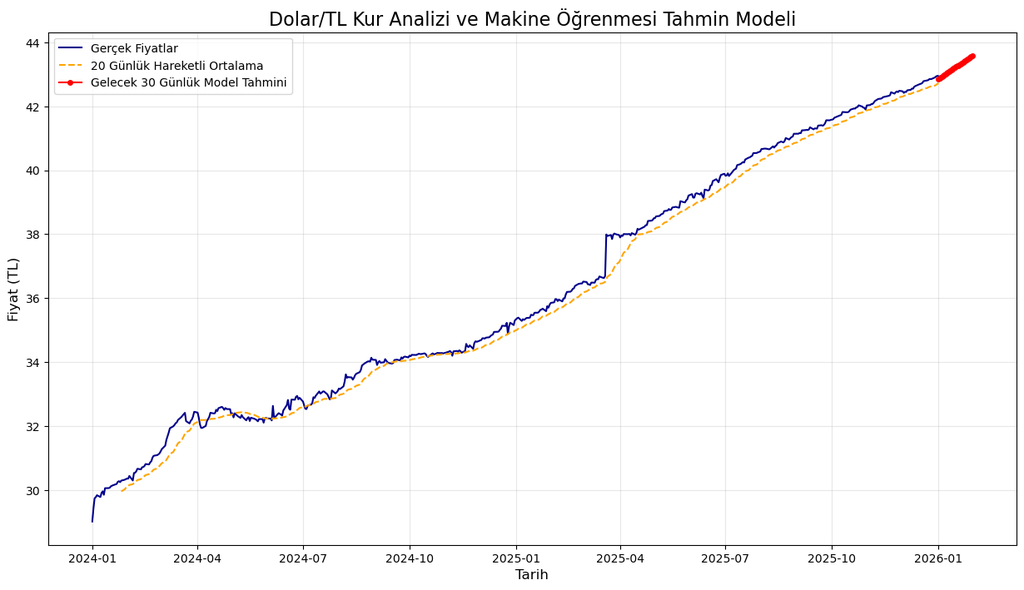

```python
plt.figure(figsize=(15, 8))

# 1. Gerçek veri çizimi
plt.plot(df.index, df['Close'], label='Gerçek Fiyatlar', color='darkblue', linewidth=1.5)

# 2. Hareketli ortalama çizimi
if 'Moving_Average' in df.columns:
    plt.plot(df.index, df['Moving_Average'], label='20 Günlük Hareketli Ortalama', color='orange', linestyle='--')

# 3. Tahminler (Gelecek 30 gün)
future_dates = pd.date_range(start=df.index[-1], periods=30)
# Boyut hatasını düzeltmek için .flatten() ekledik
plt.plot(future_dates, future_preds.flatten(), label='Gelecek 30 Günlük Model Tahmini', color='red', marker='o', markersize=4)

plt.title('Dolar/TL Kur Analizi ve Makine Öğrenmesi Tahmin Modeli', fontsize=16)
plt.xlabel('Tarih', fontsize=12)
plt.ylabel('Fiyat (TL)', fontsize=12)
plt.legend()
plt.grid(True, alpha=0.3)
plt.show()

# 4. Tahminleri dosyaya kaydetme (Boyut hatası burada çözüldü)
prediction_df = pd.DataFrame({
    'Tarih': future_dates,
    'Tahmini_Fiyat': future_preds.flatten() # .flatten() ile listeyi düzleştirdik
})
prediction_df.to_csv('USDTRY_Gelecek_Tahminleri.csv', index=False)
```